# DATA419 Tutorial

# Name: Feng Wang

# Student ID: 37115208

# Social network

This tutorial is about ‘tweet’ network. We use twitter API to search a key word to build network. We end up with graphs that show the relationship between the two nodes (user_id and status_id).

## Installing packages we need

We need to install some packages to support our analysis

```r
library(tidyverse)
```

```r
library(tidygraph)
library(igraph)
library(ggraph)
```

## Searching tweets

We can use {rtweet} to search and download data about Tesla.

```r
library(rtweet)
api_key <- 'iOsRlTvxgT2FRQgJC8MUL34w2'
api_secret_key <- 'k1dlDeAUUws2KcmAXq49R2x9ALKnOXyfhAeQOYRE9QKhd5Fjiq'
bearer_token <- 'AAAAAAAAAAAAAAAAAAAAALCndAEAAAAAH7ePVnYa4M6OVtBdb0RwCSvIVDQ%3DocaUDYhGYSwcNt2fEcikZaK1bHsKlRoE0um9hWQMWjCxxQjpdS-3VbQQP5VPp3JVj58VilKWOsUr6SZ2N'


get_token()
```

```
## <Token>
## <oauth_endpoint>
##  request:   https://api.twitter.com/oauth/request_token
##  authorize: https://api.twitter.com/oauth/authenticate
##  access:    https://api.twitter.com/oauth/access_token
## <oauth_app> rstats2twitter
##   key:    6j7Ig4xzHlBr8uUJ5A4Ym0NTf
##   secret: <hidden>
## <credentials> oauth_token, oauth_token_secret, user_id, screen_name
## ---
```

```r
tesla_tweets <- search_tweets(
      q = "#tesla", #q is the query
      n = 7000, #n is how many
      include_rts = FALSE #we only want originals
)
```

Let’s see what we have got.

```r
tesla_tweets %>%
  glimpse()
```

```
## Rows: 6,886
## Columns: 90
## $ user_id                 <chr> "1106512977660923905", "1009357757219266560", …
## $ status_id               <chr> "1533259948129492992", "1533259833230639105", …
## $ created_at              <dttm> 2022-06-05 01:30:32, 2022-06-05 01:30:05, 202…
## $ screen_name             <chr> "MesmerizeD_it", "MBrae3", "MBrae3", "MBrae3",…
## $ text                    <chr> "Who knew this? And what do you think of this …
## $ source                  <chr> "LaterMedia", "CryptoQuantBot", "CryptoQuantBo…
## $ display_text_width      <dbl> 168, 192, 193, 193, 193, 193, 193, 193, 193, 1…
## $ reply_to_status_id      <chr> NA, NA, NA, NA, NA, NA, NA, NA, NA, NA, NA, NA…
## $ reply_to_user_id        <chr> NA, NA, NA, NA, NA, NA, NA, NA, NA, NA, NA, NA…
## $ reply_to_screen_name    <chr> NA, NA, NA, NA, NA, NA, NA, NA, NA, NA, NA, NA…
## $ is_quote                <lgl> FALSE, FALSE, FALSE, FALSE, FALSE, FALSE, FALS…
## $ is_retweet              <lgl> FALSE, FALSE, FALSE, FALSE, FALSE, FALSE, FALS…
## $ favorite_count          <int> 0, 0, 0, 0, 0, 1, 1, 1, 0, 0, 0, 0, 0, 1, 0, 0…
```

[output cut: 77 more lines]

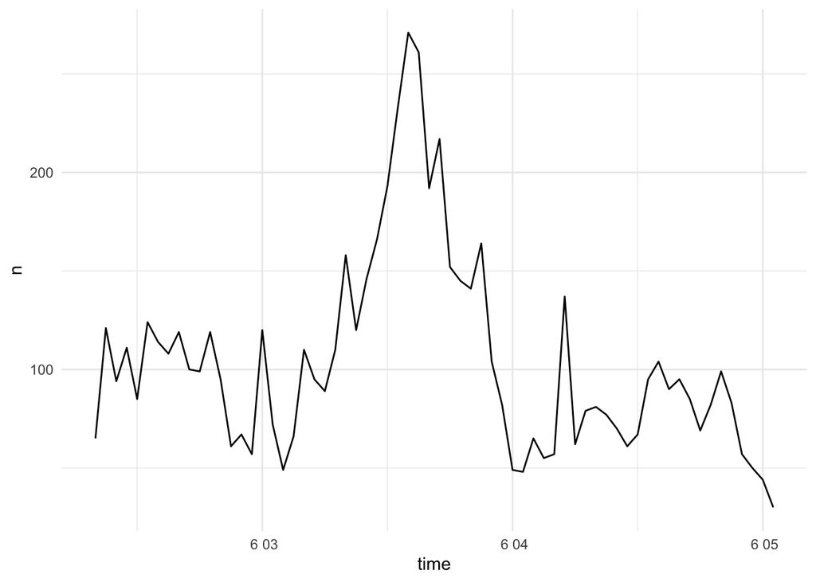

```r
ts_plot(tesla_tweets, "hours") + theme_minimal() #it produces a ggplot plot
```

We can use the users function to find out who’s the most followed account that has tweeted about tesla in our collection

```r
tesla_tweets %>%
  users_data() %>%
  arrange(desc(followers_count)) %>%
  unique()
```

```
## # A tibble: 4,084 × 20
##    user_id   screen_name   name             location description url   protected
##    <chr>     <chr>         <chr>            <chr>    <chr>       <chr> <lgl>
##  1 42606652  aajtak        AajTak           India    "AajTak co… http… FALSE
##  2 134758540 timesofindia  The Times Of In… New Del… "News. Vie… http… FALSE
##  3 39240673  ABPNews       ABP News         India    "Follow fo… http… FALSE
##  4 240649814 TimesNow      TIMES NOW        India    "TIMES NOW… http… FALSE
##  5 20751449  the_hindu     The Hindu        Chennai… "News feed… http… FALSE
##  6 461841349 ZeeNews       Zee News         India    "ज़ी न्‍यूज हिंद… http… FALSE
##  7 38647512  IndianExpress The Indian Expr… India    "The India… http… FALSE
##  8 5734902   tagesschau    tagesschau       Hamburg  "Schlagzei… http… FALSE
##  9 27708897  Reforma       REFORMA          Av. Mé…  "Periódic…  http… FALSE
## 10 50916567  NationTV22    NationTV22       Bangkok… "สถานีข่าว 2… http… FALSE
## # … with 4,074 more rows, and 13 more variables: followers_count <int>,
## #   friends_count <int>, listed_count <int>, statuses_count <int>,
## #   favourites_count <int>, account_created_at <dttm>, verified <lgl>,
## #   profile_url <chr>, profile_expanded_url <chr>, account_lang <lgl>,
## #   profile_banner_url <chr>, profile_background_url <chr>,
## #   profile_image_url <chr>
```

We can plot the distribution of the amount of followers of our accounts

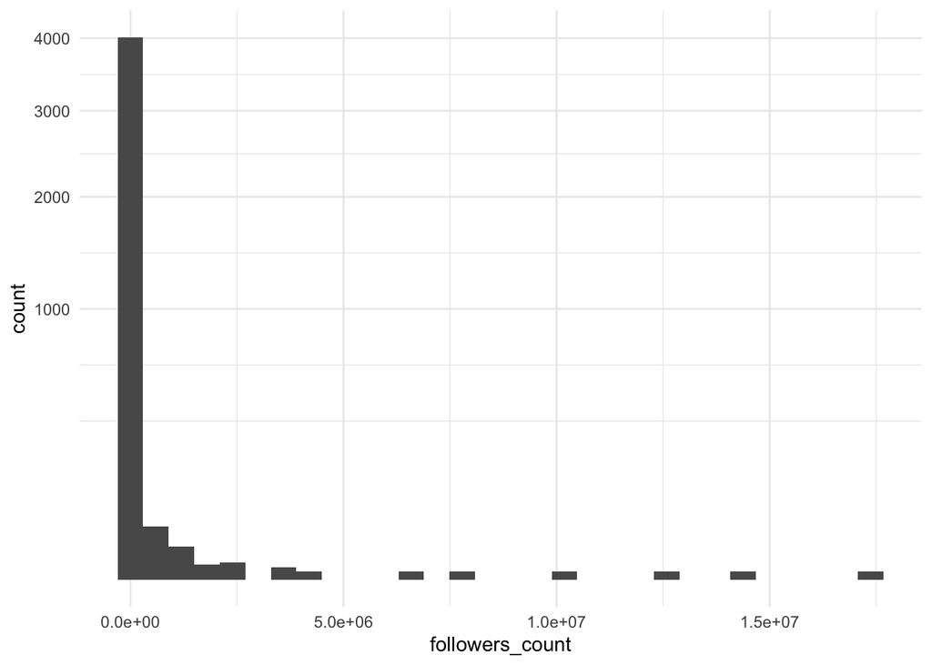

```r
tesla_tweets %>%
  users_data %>%
  arrange(desc(followers_count)) %>%
  unique() %>%
  ggplot(aes(x=followers_count)) +
    geom_histogram(bins=30) +
    scale_y_sqrt() +
    theme_minimal()
```

## Build the network

We will build the network based on the user and status variables, and then need to filter out some invalid data. We will use two function ‘select’ and ‘rename’ and change the name of the two variables.

```r
new_tesla <- tesla_tweets %>%
  filter(!is.na(user_id),
         !is.na(reply_to_status_id)) %>%
  select(user_id, reply_to_status_id) %>% #select column we need
  rename(to=user_id,from=reply_to_status_id) #change name

new_tesla %>%
  count(to) %>%
  arrange(desc(n)) %>% #arrange by n in descending order
  top_n(5,n) #get the first 5, according to n
```

```
## # A tibble: 5 × 2
##   to                      n
##   <chr>               <int>
## 1 1377967748161081349    75
## 2 1266408640292040711    55
## 3 1494780034103578631    44
## 4 1390709562727145473    43
## 5 14283770               26
```

## Degree distribution

We can take a plot that is abou empirical distribution of the degree.

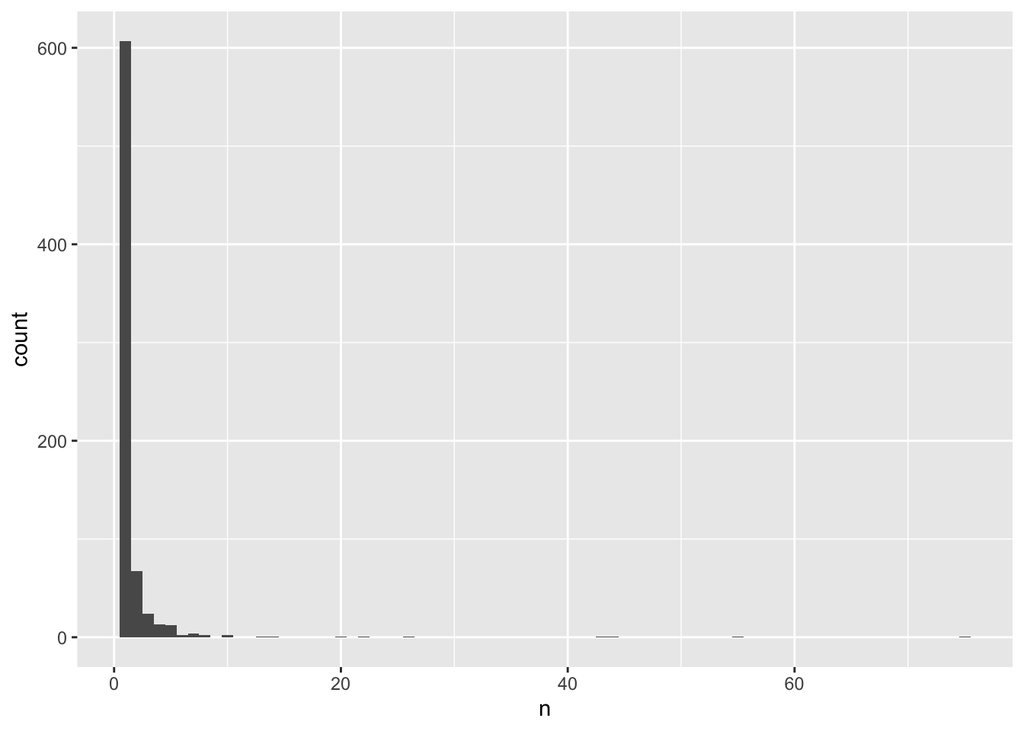

```r
new_tesla %>%
  count(to) %>%
  ggplot()+geom_histogram(aes(x=n),binwidth = 1)
```

## Igraph network

```r
new_tesla1 <- new_tesla %>%
  full_join(new_tesla, by = "from") %>% #we are full joining links with links, and connecting them via the column from
  filter(to.x != to.y)  %>% #we don't care about self links
  select(-from) %>% #we only care about the astronauts,not the missions now
  rename(from = to.x, to = to.y) #and we still want the from and to names for the columns
new_tesla1 <- new_tesla1[, c('from','to')]
new_tesla1
```

```
## # A tibble: 6,570 × 2
##    from                to
##    <chr>               <chr>
##  1 1501307542630141965 1368100356
##  2 1501307542630141965 1483371142681350146
##  3 1501307542630141965 1387349217308340227
##  4 1501307542630141965 1487174543420665863
##  5 1501307542630141965 1492510878323081216
##  6 1501307542630141965 1476485627701080064
##  7 1501307542630141965 1396612402897117184
##  8 1501307542630141965 1371765334655574023
##  9 1501307542630141965 723730502927175680
## 10 1501307542630141965 237998141
## # … with 6,560 more rows
```

Now, we can use new dataframe to build our new network and plot it.

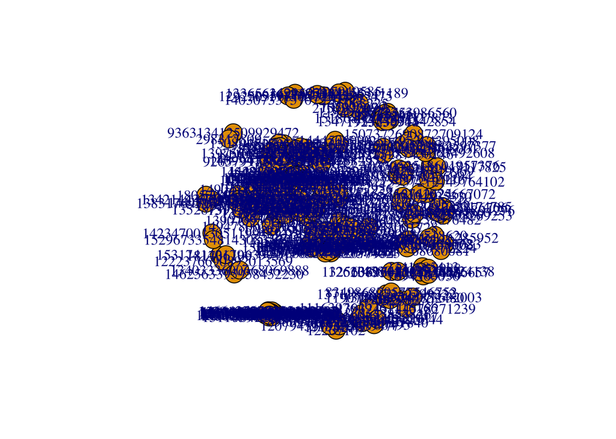

```r
new_tesla2 <- new_tesla1 %>%
  graph_from_data_frame(directed = FALSE)
new_tesla2 %>% plot() #plot
```

It looked very confused. We try to find useful information from it

We are trying to use igraph to test if the graph is connected, this will help us with our analysis

```r
new_tesla2
```

```
## IGRAPH 1af91cc UN-- 231 6570 --
## + attr: name (v/c)
## + edges from 1af91cc (vertex names):
##  [1] 1501307542630141965--1368100356
##  [2] 1501307542630141965--1483371142681350146
##  [3] 1501307542630141965--1387349217308340227
##  [4] 1501307542630141965--1487174543420665863
##  [5] 1501307542630141965--1492510878323081216
##  [6] 1501307542630141965--1476485627701080064
##  [7] 1501307542630141965--1396612402897117184
##  [8] 1501307542630141965--1371765334655574023
## + ... omitted several edges
```

```r
new_tesla2 %>% is.connected()
```

```
## [1] FALSE
```

## Tidygraph

```r
tidy_tesla <- new_tesla2 %>%
  as_tbl_graph() %>% #this transforms an igraph object in to a tidygraph object
  mutate(degree = centrality_degree()) #centrality_degree() computes the degree of the nodes in the network
tidy_tesla
```

```
## # A tbl_graph: 231 nodes and 6570 edges
## #
## # An undirected multigraph with 30 components
## #
## # Node Data: 231 × 2 (active)
##   name                degree
##   <chr>                <dbl>
## 1 1501307542630141965     26
## 2 196475531               12
## 3 1429259778325303297     94
## 4 14283770                 6
## 5 1406048249278996483      2
## 6 1368100356              26
## # … with 225 more rows
## #
## # Edge Data: 6,570 × 2
##    from    to
##   <int> <int>
## 1     1     6
## 2     1     8
## 3     1    13
## # … with 6,567 more rows
```

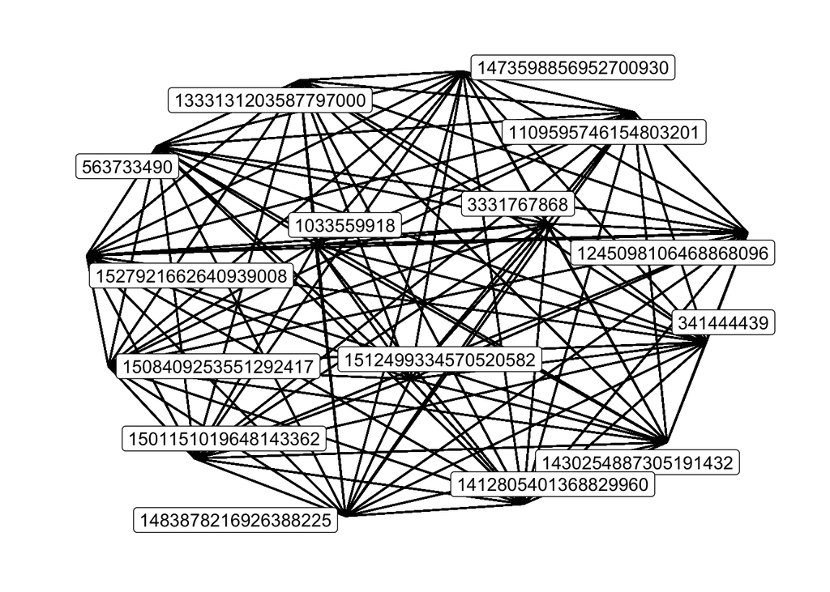

```r
new_tidy_tesla <- tidy_tesla %>%
  filter(degree > 300) %>%
  ggraph(layout = "stress") + #the layout decides the placement of the nodes on the screen
  geom_edge_link() + #how we draw the links
  geom_node_label(aes(label=name), repel =  TRUE) + #how we draw the nodes
  theme_graph() #an overall theme for the plot
new_tidy_tesla
```

We can see from the figure that many nodes have many branches

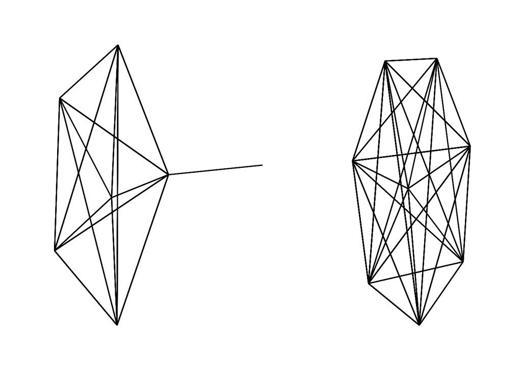

```r
new2_tidy_tesla <- tidy_tesla %>%
  filter(degree < 300 & degree > 60) %>%
  ggraph(layout = "stress") +
  geom_edge_link() +
  #geom_node_label(aes(label=name), repel =  TRUE) +
  theme_graph()
new2_tidy_tesla
```

## Degree distribution

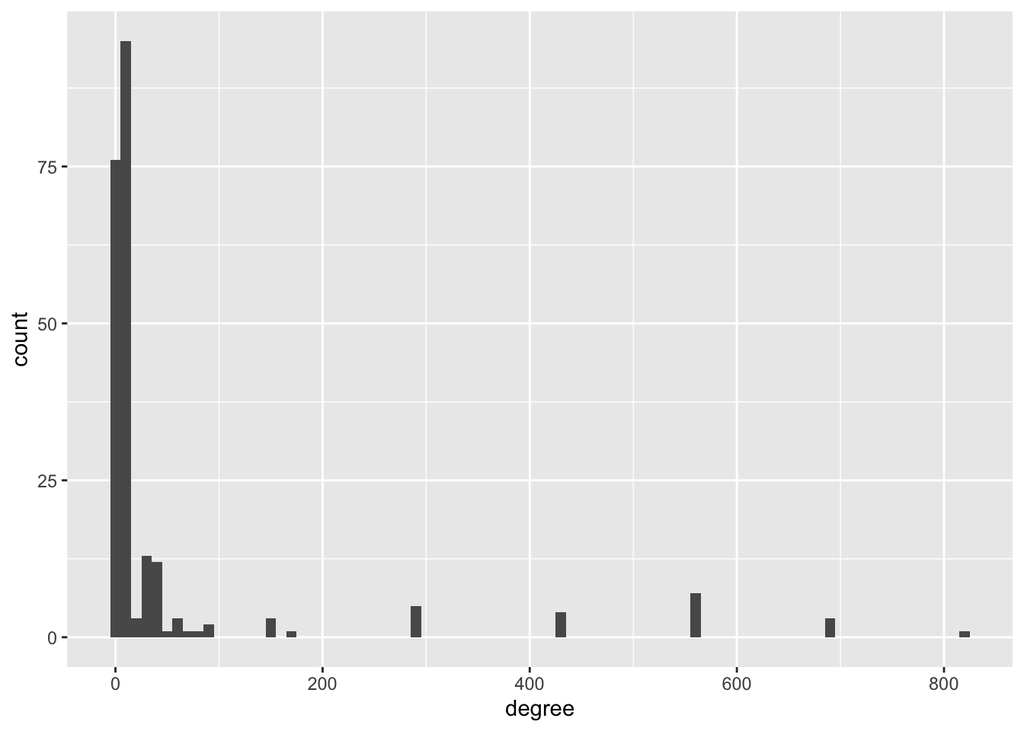

```r
tidy_tesla %>%
  as_tibble() %>%
  ggplot() +
  geom_histogram(aes(x=degree),binwidth = 10)
```

## Subgraph

```r
tidy_tesla_subgraph <- tidy_tesla %>%
  filter(degree>60 &degree<300)
```

Adjacency list:

```r
tidy_tesla_subgraph %>%
  as_adj_list()
```

```
## $`1429259778325303297`
## + 32/15 vertices, named, from 18f8694:
##  [1] 1917875473          1917875473          1917875473
##  [4] 1917875473          1410558945219973125 1410558945219973125
##  [7] 1410558945219973125 1410558945219973125 1410558945219973125
## [10] 1410558945219973125 1410558945219973125 1410558945219973125
## [13] 1266408640292040711 1266408640292040711 1266408640292040711
## [16] 1266408640292040711 1266408640292040711 1266408640292040711
## [19] 1266408640292040711 1266408640292040711 1484625399262949377
## [22] 1484625399262949377 1484625399262949377 1484625399262949377
## [25] 1484625399262949377 1484625399262949377 1484625399262949377
## [28] 1484625399262949377 1033583279990104064 1033583279990104064
## + ... omitted several vertices
##
## $`1917875473`
```

[output cut: 168 more lines]

Edge list:

```r
tidy_tesla_subgraph %>%
  as_edgelist()
```

```
##        [,1]                  [,2]
##   [1,] "1429259778325303297" "1917875473"
##   [2,] "1429259778325303297" "1410558945219973125"
##   [3,] "1429259778325303297" "1410558945219973125"
##   [4,] "1429259778325303297" "1266408640292040711"
##   [5,] "1429259778325303297" "1266408640292040711"
##   [6,] "1429259778325303297" "1484625399262949377"
##   [7,] "1429259778325303297" "1484625399262949377"
##   [8,] "1429259778325303297" "1033583279990104064"
##   [9,] "1429259778325303297" "1917875473"
##  [10,] "1429259778325303297" "1410558945219973125"
##  [11,] "1429259778325303297" "1410558945219973125"
##  [12,] "1429259778325303297" "1266408640292040711"
##  [13,] "1429259778325303297" "1266408640292040711"
##  [14,] "1429259778325303297" "1484625399262949377"
```

[output cut: 224 more lines]

Adjacency matrix:

```r
tidy_tesla_subgraph %>%
  as_adjacency_matrix(sparse = FALSE)
```

```
##                     1429259778325303297 1917875473 1492510878323081216
## 1429259778325303297                   0          4                   0
## 1917875473                            4          0                   0
## 1492510878323081216                   0          0                   0
## 1410558945219973125                   8          4                   0
## 1266408640292040711                   8          4                   2
## 1466417020258422793                   0          0                   0
## 1233439374202867713                   0          0                   0
## 1483878679428177920                   0          0                   0
## 40521992                              0          0                   0
## 1484625399262949377                   8          4                   0
## 2667583510                            0          0                   0
## 3042208749                            0          0                   0
## 1511459157123244034                   0          0                   0
## 1529190366364196865                   0          0                   0
```

[output cut: 65 more lines]

## Topological properties

We can measure topological properties at a global or local level. I’m going to use this igraph to figure out the properties

```r
tidy_tesla_subgraph %>% #the long shortest path between two nodes
  diameter()
```

```
## [1] 2
```

Girth:

```r
tidy_tesla_subgraph %>% #the length of the shortest circle
  girth()
```

```
## $girth
## [1] 3
##
## $circle
## + 3/15 vertices, named, from 18f8694:
## [1] 1917875473          1429259778325303297 1410558945219973125
```

Radius:

```r
tidy_tesla_subgraph %>% #the length of the shortest circle
  radius()
```

```
## [1] 1
```

Clustering index:

```r
tidy_tesla_subgraph %>% #the clustering coefficient
  transitivity()
```

```
## [1] 0.9785408
```

## Random network model

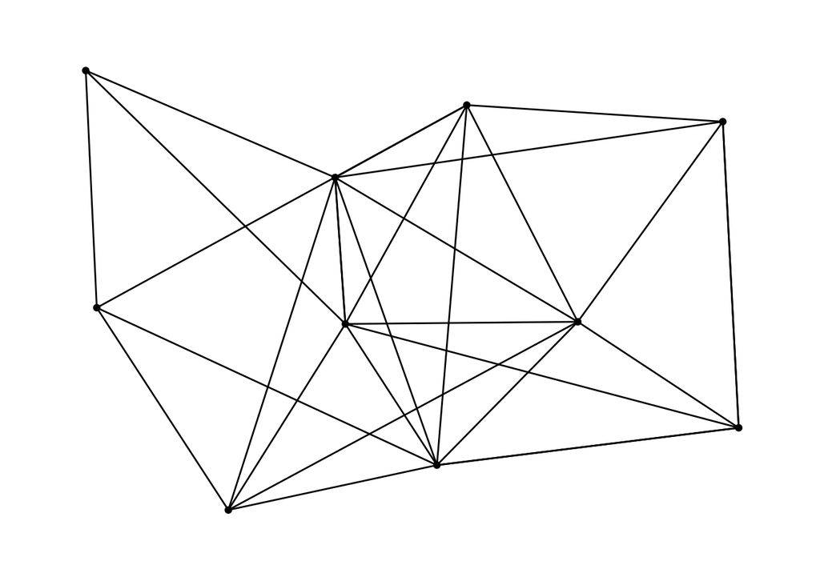

```r
set.seed(Sys.time()) #the random seed
play_erdos_renyi(n=10,m=30) %>%
  ggraph(layout="stress") +
  geom_node_point() +
  geom_edge_link() +
  theme_graph()
```

## Compare model

```r
sampled <- replicate(
  n=1000, # how many times
  expr = tidy_tesla_subgraph %>% #what function to replicate
    degree() %>% #we computer the observed degrees
    play_degree() %>%
    transitivity()
)
```

We are going to create a histogram of sampled values using {ggplot} which shows one observed value of the clustering index and 1000 sampled values of clustering index.

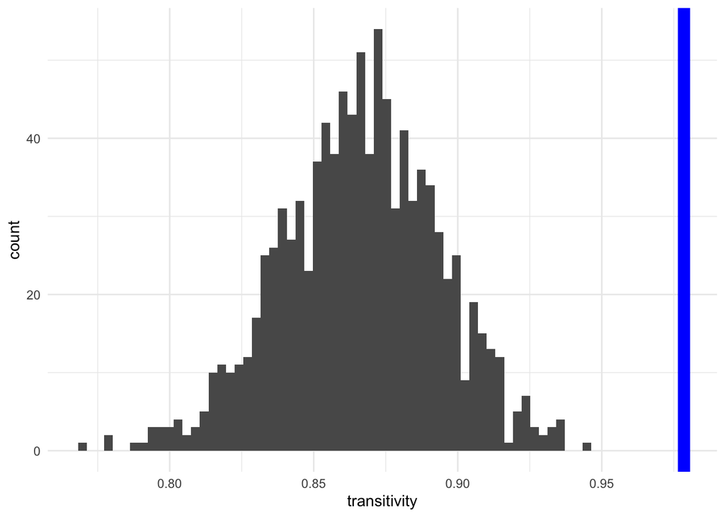

```r
sampled %>%
  tibble(transitivity=.) %>%
  ggplot(aes(x=transitivity)) +
           geom_histogram(bins=70) +
           geom_vline(xintercept = tidy_tesla_subgraph %>% transitivity(),
                      color = 'blue',
                      size=4) +
           theme_minimal()
```

The clustering coeffcient values of the model we chose are quite different from those observed. This shows that the degree sequence of all these networks is the same, and a fixed degree sequence is not a good choice for our network.